# Loan Model Project / Yeoman Yoon

## Import libraries and dataset

```python
import pandas as pd
import numpy as np
from sklearn import metrics
import matplotlib.pyplot as plt
%matplotlib inline
import seaborn as sns
from sklearn.model_selection import train_test_split
from sklearn.tree import DecisionTreeClassifier
from sklearn import tree
```

```python
data = pd.read_csv('Loan_Modelling.csv')
```

```python
print(f"There are {data.shape[1]} columns and {data.shape[0]} rows in the dataset ")
data.head(10)
```

```
There are 14 columns and 5000 rows in the dataset
```

|  | ID | Age | Experience | Income | ZIPCode | Family | CCAvg | Education | Mortgage | Personal_Loan | Securities_Account | CD_Account | Online | CreditCard |
| --- | --- | --- | --- | --- | --- | --- | --- | --- | --- | --- | --- | --- | --- | --- |
| 0 | 1 | 25 | 1 | 49 | 91107 | 4 | 1.6 | 1 | 0 | 0 | 1 | 0 | 0 | 0 |
| 1 | 2 | 45 | 19 | 34 | 90089 | 3 | 1.5 | 1 | 0 | 0 | 1 | 0 | 0 | 0 |
| 2 | 3 | 39 | 15 | 11 | 94720 | 1 | 1.0 | 1 | 0 | 0 | 0 | 0 | 0 | 0 |
| 3 | 4 | 35 | 9 | 100 | 94112 | 1 | 2.7 | 2 | 0 | 0 | 0 | 0 | 0 | 0 |
| 4 | 5 | 35 | 8 | 45 | 91330 | 4 | 1.0 | 2 | 0 | 0 | 0 | 0 | 0 | 1 |
| 5 | 6 | 37 | 13 | 29 | 92121 | 4 | 0.4 | 2 | 155 | 0 | 0 | 0 | 1 | 0 |
| 6 | 7 | 53 | 27 | 72 | 91711 | 2 | 1.5 | 2 | 0 | 0 | 0 | 0 | 1 | 0 |
| 7 | 8 | 50 | 24 | 22 | 93943 | 1 | 0.3 | 3 | 0 | 0 | 0 | 0 | 0 | 1 |
| 8 | 9 | 35 | 10 | 81 | 90089 | 3 | 0.6 | 2 | 104 | 0 | 0 | 0 | 1 | 0 |
| 9 | 10 | 34 | 9 | 180 | 93023 | 1 | 8.9 | 3 | 0 | 1 | 0 | 0 | 0 | 0 |

## Data Dictionary

- ID: Customer ID
- Age: Customer’s age in completed years
- Experience: #years of professional experience
- Income: Annual income of the customer (in thousand dollars)
- ZIP Code: Home Address ZIP code.
- Family: the Family size of the customer
- CCAvg: Average spending on credit cards per month (in thousand dollars)
- Education: Education Level. 1: Undergrad; 2: Graduate;3: Advanced/Professional
- Mortgage: Value of house mortgage if any. (in thousand dollars)
- Personal_Loan: Did this customer accept the personal loan offered in the last campaign? → **Dependent variable**
- Securities_Account: Does the customer have securities account with the bank?
- CD_Account: Does the customer have a certificate of deposit (CD) account with the bank?
- Online: Do customers use internet banking facilities?
- CreditCard: Does the customer use a credit card issued by any other Bank (excluding All life Bank)?

```python
data.drop(["ID"], axis=1, inplace = True) # Drop ID, we are not using this, ZIP Code maybe irrelavent. (will keep for now)

# data.drop(["ID", "ZIPCode", "Securities_Account", "CD_Account", "Online", "CreditCard"], axis=1, inplace = True) # Dropping these didn't change the result much.
```

```python
data.info() #no missing values. good data type.
```

```
<class 'pandas.core.frame.DataFrame'>
RangeIndex: 5000 entries, 0 to 4999
Data columns (total 13 columns):
Age                   5000 non-null int64
Experience            5000 non-null int64
Income                5000 non-null int64
ZIPCode               5000 non-null int64
Family                5000 non-null int64
CCAvg                 5000 non-null float64
Education             5000 non-null int64
Mortgage              5000 non-null int64
Personal_Loan         5000 non-null int64
Securities_Account    5000 non-null int64
CD_Account            5000 non-null int64
Online                5000 non-null int64
CreditCard            5000 non-null int64
dtypes: float64(1), int64(12)
memory usage: 507.9 KB
```

```python
data.describe().T # negative number is definately an error. some outliers in income, CCAvg and Mortgage
```

|  | count | mean | std | min | 25% | 50% | 75% | max |
| --- | --- | --- | --- | --- | --- | --- | --- | --- |
| Age | 5000.0 | 45.338400 | 11.463166 | 23.0 | 35.0 | 45.0 | 55.0 | 67.0 |
| Experience | 5000.0 | 20.104600 | 11.467954 | -3.0 | 10.0 | 20.0 | 30.0 | 43.0 |
| Income | 5000.0 | 73.774200 | 46.033729 | 8.0 | 39.0 | 64.0 | 98.0 | 224.0 |
| ZIPCode | 5000.0 | 93169.257000 | 1759.455086 | 90005.0 | 91911.0 | 93437.0 | 94608.0 | 96651.0 |
| Family | 5000.0 | 2.396400 | 1.147663 | 1.0 | 1.0 | 2.0 | 3.0 | 4.0 |
| CCAvg | 5000.0 | 1.937938 | 1.747659 | 0.0 | 0.7 | 1.5 | 2.5 | 10.0 |
| Education | 5000.0 | 1.881000 | 0.839869 | 1.0 | 1.0 | 2.0 | 3.0 | 3.0 |
| Mortgage | 5000.0 | 56.498800 | 101.713802 | 0.0 | 0.0 | 0.0 | 101.0 | 635.0 |
| Personal_Loan | 5000.0 | 0.096000 | 0.294621 | 0.0 | 0.0 | 0.0 | 0.0 | 1.0 |
| Securities_Account | 5000.0 | 0.104400 | 0.305809 | 0.0 | 0.0 | 0.0 | 0.0 | 1.0 |
| CD_Account | 5000.0 | 0.060400 | 0.238250 | 0.0 | 0.0 | 0.0 | 0.0 | 1.0 |
| Online | 5000.0 | 0.596800 | 0.490589 | 0.0 | 0.0 | 1.0 | 1.0 | 1.0 |
| CreditCard | 5000.0 | 0.294000 | 0.455637 | 0.0 | 0.0 | 0.0 | 1.0 | 1.0 |

## Error Correction (No missing variables)

Experience has negative values

```python
# (data["Experience"]<0).value_counts(ascending = True)
# data["Experience"].value_counts(ascending = True)

data["Experience"][data["Experience"]<4].value_counts()
```

```
 3    129
 2     85
 1     74
 0     66
-1     33
-2     15
-3      4
Name: Experience, dtype: int64
```

Negative value may represent 0 or absolute value of itself.  
My Decision: all 0.  
My Reason: if numbers accidentally had negative sign, it is likely that value count of negetives will be symetric in count with postives, but it is going down.

```python
# data["Experience"][data["Experience"]<0] = 0 # gives error

data["Experience"] = data["Experience"].replace([-1,-2,-3],0)
```

## Univariate Analysis:

### distplot(preferably continuous variable):

Age, Experience, Income, ZIPCode, CCAvg, Mortgage

### countplot(preferably categorical variable):

Family, Education, Personal_Loan, Securities_Account, CD_Account, Online, CreditCard

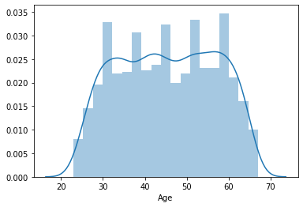

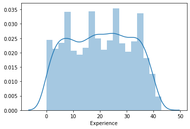

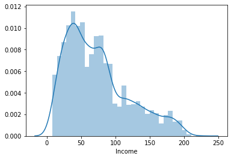

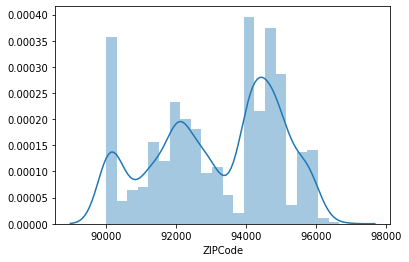

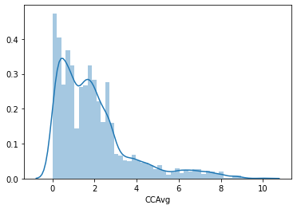

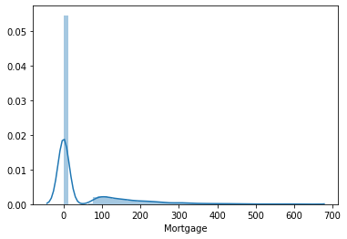

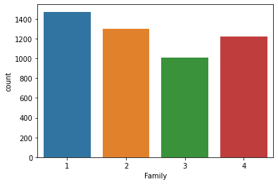

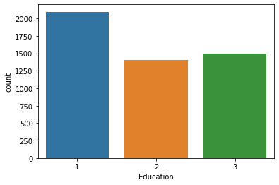

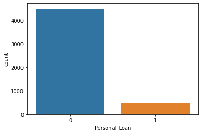

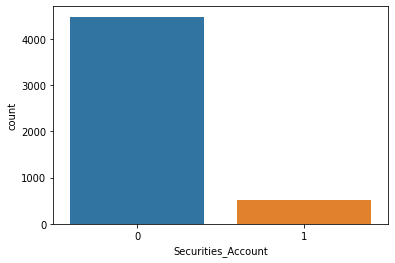

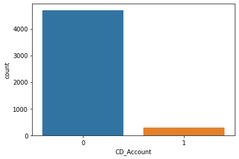

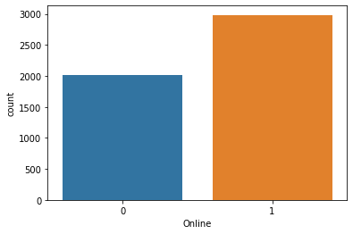

[1 more figures not shown]

```python
distPlotList = ["Age", "Experience", "Income", "ZIPCode", "CCAvg", "Mortgage"]
countPlotList = [ "Family", "Education", "Personal_Loan",
                 "Securities_Account", "CD_Account", "Online", "CreditCard"]
for i in distPlotList:
    sns.distplot(data[i])
    plt.show()

for i in countPlotList:
    sns.countplot(data[i])
    plt.show()
```

```python
a= data["Mortgage"][data["Mortgage"]==0].value_counts().sum()
b= data["Mortgage"][data["Mortgage"]!=0].value_counts().sum()

print (f"{a},{b}")
```

```
3462,1538
```

Personal Loan, Securities Account, and CD Account have serious unbalanced spread of data.  
Age and Experience has very similar graph.  
Some high sticking points in age and experience make me doubt if the data was pre-binned in some places.  
Consider binning Mortgage with 0 and 1.

## Bivariate analysis

```python
data.corr()
```

|  | Age | Experience | Income | ZIPCode | Family | CCAvg | Education | Mortgage | Personal_Loan | Securities_Account | CD_Account | Online | CreditCard |
| --- | --- | --- | --- | --- | --- | --- | --- | --- | --- | --- | --- | --- | --- |
| Age | 1.000000 | 0.994198 | -0.055269 | -0.030530 | -0.046418 | -0.052012 | 0.041334 | -0.012539 | -0.007726 | -0.000436 | 0.008043 | 0.013702 | 0.007681 |
| Experience | 0.994198 | 1.000000 | -0.046729 | -0.030649 | -0.052213 | -0.049912 | 0.013536 | -0.010840 | -0.007858 | -0.001111 | 0.010046 | 0.013975 | 0.008910 |
| Income | -0.055269 | -0.046729 | 1.000000 | -0.030709 | -0.157501 | 0.645984 | -0.187524 | 0.206806 | 0.502462 | -0.002616 | 0.169738 | 0.014206 | -0.002385 |
| ZIPCode | -0.030530 | -0.030649 | -0.030709 | 1.000000 | 0.027512 | -0.012188 | -0.008266 | 0.003614 | -0.002974 | 0.002422 | 0.021671 | 0.028317 | 0.024033 |
| Family | -0.046418 | -0.052213 | -0.157501 | 0.027512 | 1.000000 | -0.109275 | 0.064929 | -0.020445 | 0.061367 | 0.019994 | 0.014110 | 0.010354 | 0.011588 |
| CCAvg | -0.052012 | -0.049912 | 0.645984 | -0.012188 | -0.109275 | 1.000000 | -0.136124 | 0.109905 | 0.366889 | 0.015086 | 0.136534 | -0.003611 | -0.006689 |
| Education | 0.041334 | 0.013536 | -0.187524 | -0.008266 | 0.064929 | -0.136124 | 1.000000 | -0.033327 | 0.136722 | -0.010812 | 0.013934 | -0.015004 | -0.011014 |
| Mortgage | -0.012539 | -0.010840 | 0.206806 | 0.003614 | -0.020445 | 0.109905 | -0.033327 | 1.000000 | 0.142095 | -0.005411 | 0.089311 | -0.005995 | -0.007231 |
| Personal_Loan | -0.007726 | -0.007858 | 0.502462 | -0.002974 | 0.061367 | 0.366889 | 0.136722 | 0.142095 | 1.000000 | 0.021954 | 0.316355 | 0.006278 | 0.002802 |
| Securities_Account | -0.000436 | -0.001111 | -0.002616 | 0.002422 | 0.019994 | 0.015086 | -0.010812 | -0.005411 | 0.021954 | 1.000000 | 0.317034 | 0.012627 | -0.015028 |
| CD_Account | 0.008043 | 0.010046 | 0.169738 | 0.021671 | 0.014110 | 0.136534 | 0.013934 | 0.089311 | 0.316355 | 0.317034 | 1.000000 | 0.175880 | 0.278644 |
| Online | 0.013702 | 0.013975 | 0.014206 | 0.028317 | 0.010354 | -0.003611 | -0.015004 | -0.005995 | 0.006278 | 0.012627 | 0.175880 | 1.000000 | 0.004210 |
| CreditCard | 0.007681 | 0.008910 | -0.002385 | 0.024033 | 0.011588 | -0.006689 | -0.011014 | -0.007231 | 0.002802 | -0.015028 | 0.278644 | 0.004210 | 1.000000 |

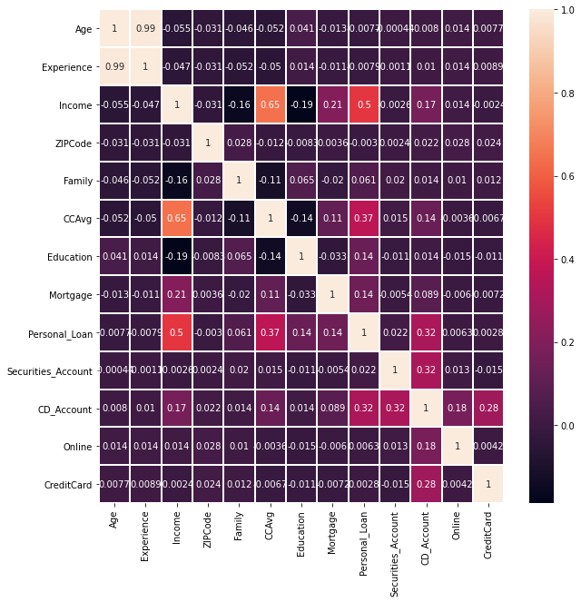

```python
plt.subplots(figsize=(10,10))
sns.heatmap(data.corr(), annot =True, linewidth=1)
```

It is important to note Age and Experience has correlation of almost 1 and very similar correlations with other variables as well.  
Zipcode has almost no correlation with any variables ( |x| < 0.035 )  
Consider dropping both.

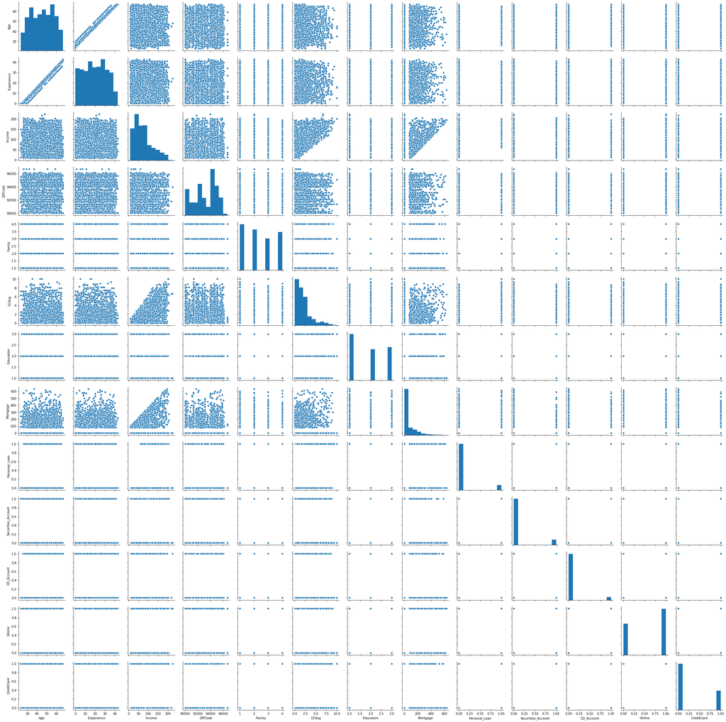

```python
sns.pairplot(data)
```

Correlation of Age and Experience is too high.  
CCAvg, Personal Loan, and Income have significant correlation to each other.

## Data Cleaning

Require dummie variables, Binning zipcode

```python
# data['ZIPCode'].unique() # 90xxx ~ 96xxx
```

```python
binned_ZIPCode = pd.cut(data["ZIPCode"],[90000, 91000, 92000, 93000, 94000, 95000, 97000])
```

```python
binned_ZIPCode.value_counts()
```

```
(94000, 95000]    1472
(92000, 93000]     988
(95000, 97000]     855
(90000, 91000]     703
(91000, 92000]     565
(93000, 94000]     417
Name: ZIPCode, dtype: int64
```

```python
data['binned_ZIPCode'] = pd.cut(
    data["ZIPCode"], [90000, 91000, 92000, 93000, 94000, 95000, 97000],
    labels = ["90001 to 91000", "91001 to 92000", "92001 to 93000", "93001 to 94000", "94001 to 95000", "95001 to 97000"]
)

data.drop(["ZIPCode"], axis= 1, inplace =True)
```

```python
data.head()
```

|  | Age | Experience | Income | Family | CCAvg | Education | Mortgage | Personal_Loan | Securities_Account | CD_Account | Online | CreditCard | binned_ZIPCode |
| --- | --- | --- | --- | --- | --- | --- | --- | --- | --- | --- | --- | --- | --- |
| 0 | 25 | 1 | 49 | 4 | 1.6 | 1 | 0 | 0 | 1 | 0 | 0 | 0 | 91001 to 92000 |
| 1 | 45 | 19 | 34 | 3 | 1.5 | 1 | 0 | 0 | 1 | 0 | 0 | 0 | 90001 to 91000 |
| 2 | 39 | 15 | 11 | 1 | 1.0 | 1 | 0 | 0 | 0 | 0 | 0 | 0 | 94001 to 95000 |
| 3 | 35 | 9 | 100 | 1 | 2.7 | 2 | 0 | 0 | 0 | 0 | 0 | 0 | 94001 to 95000 |
| 4 | 35 | 8 | 45 | 4 | 1.0 | 2 | 0 | 0 | 0 | 0 | 0 | 1 | 91001 to 92000 |

```python
data = pd.get_dummies(data, columns=["binned_ZIPCode"])
data.head()
```

|  | Age | Experience | Income | Family | CCAvg | Education | Mortgage | Personal_Loan | Securities_Account | CD_Account | Online | CreditCard | binned_ZIPCode_90001 to 91000 | binned_ZIPCode_91001 to 92000 | binned_ZIPCode_92001 to 93000 | binned_ZIPCode_93001 to 94000 | binned_ZIPCode_94001 to 95000 | binned_ZIPCode_95001 to 97000 |
| --- | --- | --- | --- | --- | --- | --- | --- | --- | --- | --- | --- | --- | --- | --- | --- | --- | --- | --- |
| 0 | 25 | 1 | 49 | 4 | 1.6 | 1 | 0 | 0 | 1 | 0 | 0 | 0 | 0 | 1 | 0 | 0 | 0 | 0 |
| 1 | 45 | 19 | 34 | 3 | 1.5 | 1 | 0 | 0 | 1 | 0 | 0 | 0 | 1 | 0 | 0 | 0 | 0 | 0 |
| 2 | 39 | 15 | 11 | 1 | 1.0 | 1 | 0 | 0 | 0 | 0 | 0 | 0 | 0 | 0 | 0 | 0 | 1 | 0 |
| 3 | 35 | 9 | 100 | 1 | 2.7 | 2 | 0 | 0 | 0 | 0 | 0 | 0 | 0 | 0 | 0 | 0 | 1 | 0 |
| 4 | 35 | 8 | 45 | 4 | 1.0 | 2 | 0 | 0 | 0 | 0 | 0 | 1 | 0 | 1 | 0 | 0 | 0 | 0 |

```python
# data.drop(["Age"], axis=1 ,inplace =True) #Dropping Age didn't change accuracy of Logistic Regression...&
```

Even though the ZIP Code is continuous with region, it is not obvious regions have similar characteristics. Therefore, categorized and created dummi-variables.

## Data Distribution for Test

```python
X = data.drop("Personal_Loan", axis =1)
Y = data["Personal_Loan"]

x_train, x_test, y_train, y_test = train_test_split(X, Y, test_size=0.3, random_state=1)
```

```python
print("{0:0.2f}% data is in training set".format((len(x_train)/len(data.index)) * 100))
print("{0:0.2f}% data is in test set".format((len(x_test)/len(data.index)) * 100))
```

```
70.00% data is in training set
30.00% data is in test set
```

### Data Balancing

Personal Loan, Securities Account, and CD Account have serious unbalanced spread of data.

```python
print("Original Personal_Loan True Values    : {0} ({1:0.2f}%)".format(len(data.loc[data['Personal_Loan'] == 1]), (len(data.loc[data['Personal_Loan'] == 1])/len(data.index)) * 100))
print("Original Personal_Loan False Values   : {0} ({1:0.2f}%)".format(len(data.loc[data['Personal_Loan'] == 0]), (len(data.loc[data['Personal_Loan'] == 0])/len(data.index)) * 100))
print("")
print("Training Personal_Loan True Values    : {0} ({1:0.2f}%)".format(len(y_train[y_train[:] == 1]), (len(y_train[y_train[:] == 1])/len(y_train)) * 100))
print("Training Personal_Loan False Values   : {0} ({1:0.2f}%)".format(len(y_train[y_train[:] == 0]), (len(y_train[y_train[:] == 0])/len(y_train)) * 100))
print("")
print("Test Personal_Loan True Values        : {0} ({1:0.2f}%)".format(len(y_test[y_test[:] == 1]), (len(y_test[y_test[:] == 1])/len(y_test)) * 100))
print("Test Personal_Loan False Values       : {0} ({1:0.2f}%)".format(len(y_test[y_test[:] == 0]), (len(y_test[y_test[:] == 0])/len(y_test)) * 100))
print("")
```

```
Original Personal_Loan True Values    : 480 (9.60%)
Original Personal_Loan False Values   : 4520 (90.40%)

Training Personal_Loan True Values    : 331 (9.46%)
Training Personal_Loan False Values   : 3169 (90.54%)

Test Personal_Loan True Values        : 149 (9.93%)
Test Personal_Loan False Values       : 1351 (90.07%)
```

```python
print("Original Securities_Account True Values    : {0} ({1:0.2f}%)".format(len(data.loc[data['Securities_Account'] == 1]), (len(data.loc[data['Securities_Account'] == 1])/len(data.index)) * 100))
print("Original Securities_Account False Values   : {0} ({1:0.2f}%)".format(len(data.loc[data['Securities_Account'] == 0]), (len(data.loc[data['Securities_Account'] == 0])/len(data.index)) * 100))
print("")
print("Training Securities_Account True Values    : {0} ({1:0.2f}%)".format(len(x_train[x_train['Securities_Account'] == 1]), (len(x_train[x_train['Securities_Account'] == 1])/len(x_train)) * 100))
print("Training Securities_Account False Values   : {0} ({1:0.2f}%)".format(len(x_train[x_train['Securities_Account'] == 0]), (len(x_train[x_train['Securities_Account'] == 0])/len(x_train)) * 100))
print("")
print("Test Securities_Account True Values        : {0} ({1:0.2f}%)".format(len(x_test[x_test['Securities_Account'] == 1]), (len(x_test[x_test['Securities_Account'] == 1])/len(x_test)) * 100))
print("Test Securities_Account False Values       : {0} ({1:0.2f}%)".format(len(x_test[x_test['Securities_Account'] == 0]), (len(x_test[x_test['Securities_Account'] == 0])/len(x_test)) * 100))
print("")
```

```
Original Securities_Account True Values    : 522 (10.44%)
Original Securities_Account False Values   : 4478 (89.56%)

Training Securities_Account True Values    : 366 (10.46%)
Training Securities_Account False Values   : 3134 (89.54%)

Test Securities_Account True Values        : 156 (10.40%)
Test Securities_Account False Values       : 1344 (89.60%)
```

```python
print("Original CD_Account True Values    : {0} ({1:0.2f}%)".format(len(data.loc[data['CD_Account'] == 1]), (len(data.loc[data['CD_Account'] == 1])/len(data.index)) * 100))
print("Original CD_Account False Values   : {0} ({1:0.2f}%)".format(len(data.loc[data['CD_Account'] == 0]), (len(data.loc[data['CD_Account'] == 0])/len(data.index)) * 100))
print("")
print("Training CD_Account True Values    : {0} ({1:0.2f}%)".format(len(x_train[x_train['CD_Account'] == 1]), (len(x_train[x_train['CD_Account'] == 1])/len(x_train)) * 100))
print("Training CD_Account False Values   : {0} ({1:0.2f}%)".format(len(x_train[x_train['CD_Account'] == 0]), (len(x_train[x_train['CD_Account'] == 0])/len(x_train)) * 100))
print("")
print("Test CD_Account True Values        : {0} ({1:0.2f}%)".format(len(x_test[x_test['CD_Account'] == 1]), (len(x_test[x_test['CD_Account'] == 1])/len(x_test)) * 100))
print("Test CD_Account False Values       : {0} ({1:0.2f}%)".format(len(x_test[x_test['CD_Account'] == 0]), (len(x_test[x_test['CD_Account'] == 0])/len(x_test)) * 100))
print("")
```

```
Original CD_Account True Values    : 302 (6.04%)
Original CD_Account False Values   : 4698 (93.96%)

Training CD_Account True Values    : 219 (6.26%)
Training CD_Account False Values   : 3281 (93.74%)

Test CD_Account True Values        : 83 (5.53%)
Test CD_Account False Values       : 1417 (94.47%)
```

## Logistic Regression

```python
from sklearn import metrics
from sklearn.linear_model import LogisticRegression

# Fit the model on train
model = LogisticRegression(solver="liblinear",class_weight="balanced")
model.fit(x_train, y_train)
#predict on test



y_predict_LR = model.predict(x_test)

coef_df = pd.DataFrame(model.coef_)
coef_df['intercept'] = model.intercept_
print(coef_df)
```

```
          0         1         2         3        4         5         6  \
0 -0.235298  0.229293  0.050007  0.543203  0.27756  1.277733  0.000494

          7         8        9        10        11      12       13        14  \
0 -1.396873  3.628517 -0.54137 -1.053017 -0.487549 -0.4975 -0.50426 -0.607696

         15        16  intercept
0 -0.496149 -0.640155  -3.233309
```

```python
# ? LogisticRegression
```

0 Age,  
1 Experience,  
2 Income,  
3 Family,  
4 CCAvg,  
5 Education,  
6 Mortgage,  
7 Securities_Account,  
8 CD_Account,  
9 Online,  
10 CreditCard,  
11~16 ZIPCode

```python
model_score = model.score(x_test, y_test)
print(model_score)
```

```
0.8913333333333333
```

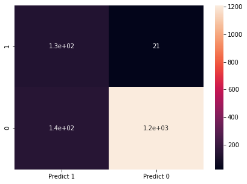

```python
cm_LR=metrics.confusion_matrix(y_test, y_predict_LR, labels=[1, 0])

df_cm = pd.DataFrame(cm_LR, index = [i for i in ["1","0"]],
                  columns = [i for i in ["Predict 1","Predict 0"]])
plt.figure(figsize = (7,5))
sns.heatmap(df_cm, annot=True)
```

```python
print(cm_LR[0])
print(cm_LR[1])
```

```
[128  21]
[ 142 1209]
```

```python
recall_LR = cm_LR[0][0]/(cm_LR[0][0]+cm_LR[0][1])
recall_LR
```

```
0.8590604026845637
```

```python
specificity_LR = cm_LR[1][1]/(cm_LR[1][1]+cm_LR[1][0])
specificity_LR
```

```
0.8948926720947447
```

class_weight="balanced" made Recall 85.9% (overall accuracy did go down to 89%)

## Decision Tree

```python
dTree = DecisionTreeClassifier(criterion = 'gini', max_depth = 6,random_state=1,class_weight="balanced")
dTree.fit(x_train, y_train)

y_predict_Tree = dTree.predict(x_test)
```

```python
# len(y_predict_Tree)
```

```python
print("Accuracy on training set : ",dTree.score(x_train, y_train))
print("Accuracy on test set : ",dTree.score(x_test, y_test))
```

```
Accuracy on training set :  0.9751428571428571
Accuracy on test set :  0.962
```

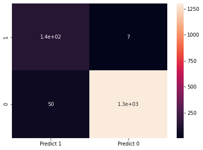

```python
cm_Tree=metrics.confusion_matrix(y_test, y_predict_Tree, labels=[1, 0])

df_cm = pd.DataFrame(cm_Tree, index = [i for i in ["1","0"]],
                  columns = [i for i in ["Predict 1","Predict 0"]])
plt.figure(figsize = (7,5))
sns.heatmap(df_cm, annot=True)
```

```python
print(cm_Tree[0])
print(cm_Tree[1])
```

```
[142   7]
[  50 1301]
```

```python
recall_Tree = cm_Tree[0][0]/(cm_Tree[0][0]+cm_Tree[0][1])
recall_Tree
```

```
0.9530201342281879
```

```python
specificity_Tree = cm_Tree[1][1]/(cm_Tree[1][1]+cm_Tree[1][0])
specificity_Tree
```

```
0.9629903774981495
```

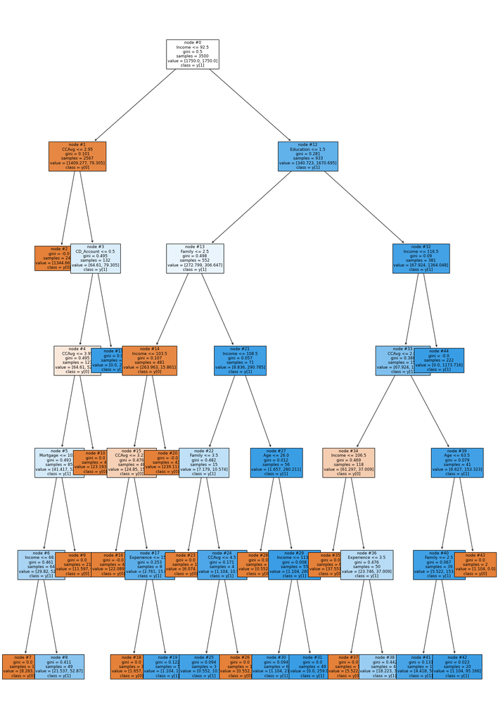

```python
plt.figure(figsize=(20,30))
tree.plot_tree(dTree,feature_names=list(X.columns),filled=True,fontsize=9,node_ids=True,class_names=True)
plt.show()
```

Accuracy goes up significantly until max depth of 6. class_weight="balanced" made recall value to go higher.

From looking at the Tree, only: **[Income, CCAvg, Education, CD_Account, Family, Mortgage, Age, Experience]** were used.

This may indicate all the other columns/variables are meaningless. --> after testing without them it is almost the same. but for the sake of project I will leave them.

Income is the most important variable in this model (Root Node)

## ERROR EDA

```python
prediction_Tree = pd.concat([x_test, y_test], axis=1) # merge the test set.
prediction_Tree["prediction"] = y_predict_Tree # add prediction

wrong_prediction_FN = prediction_Tree[prediction_Tree["prediction"]==0][prediction_Tree["Personal_Loan"]==1].copy() #False Negative
wrong_prediction_FN
```

|  | Age | Experience | Income | Family | CCAvg | Education | Mortgage | Securities_Account | CD_Account | Online | CreditCard | binned_ZIPCode_90001 to 91000 | binned_ZIPCode_91001 to 92000 | binned_ZIPCode_92001 to 93000 | binned_ZIPCode_93001 to 94000 | binned_ZIPCode_94001 to 95000 | binned_ZIPCode_95001 to 97000 | Personal_Loan | prediction |
| --- | --- | --- | --- | --- | --- | --- | --- | --- | --- | --- | --- | --- | --- | --- | --- | --- | --- | --- | --- |
| 349 | 26 | 2 | 60 | 2 | 3.0 | 1 | 132 | 0 | 0 | 0 | 0 | 0 | 0 | 0 | 1 | 0 | 0 | 1 | 0 |
| 927 | 65 | 40 | 95 | 3 | 3.7 | 2 | 138 | 0 | 0 | 0 | 1 | 0 | 0 | 0 | 0 | 0 | 1 | 1 | 0 |
| 1518 | 43 | 17 | 64 | 4 | 3.0 | 3 | 221 | 0 | 0 | 1 | 0 | 0 | 0 | 0 | 0 | 0 | 1 | 1 | 0 |
| 1577 | 34 | 8 | 65 | 1 | 3.0 | 1 | 227 | 0 | 0 | 1 | 0 | 0 | 0 | 1 | 0 | 0 | 0 | 1 | 0 |
| 1126 | 32 | 8 | 104 | 2 | 3.7 | 1 | 0 | 0 | 0 | 0 | 1 | 0 | 0 | 0 | 0 | 0 | 1 | 1 | 0 |
| 2539 | 32 | 7 | 98 | 1 | 4.2 | 1 | 171 | 1 | 1 | 0 | 0 | 0 | 0 | 0 | 0 | 0 | 1 | 1 | 0 |
| 671 | 65 | 41 | 105 | 1 | 3.0 | 2 | 282 | 1 | 1 | 1 | 0 | 0 | 0 | 1 | 0 | 0 | 0 | 1 | 0 |

```python
wrong_prediction_FP = prediction_Tree[prediction_Tree["prediction"]==1][prediction_Tree["Personal_Loan"]==0].copy() # False Positive
wrong_prediction_FP
```

|  | Age | Experience | Income | Family | CCAvg | Education | Mortgage | Securities_Account | CD_Account | Online | CreditCard | binned_ZIPCode_90001 to 91000 | binned_ZIPCode_91001 to 92000 | binned_ZIPCode_92001 to 93000 | binned_ZIPCode_93001 to 94000 | binned_ZIPCode_94001 to 95000 | binned_ZIPCode_95001 to 97000 | Personal_Loan | prediction |
| --- | --- | --- | --- | --- | --- | --- | --- | --- | --- | --- | --- | --- | --- | --- | --- | --- | --- | --- | --- |
| 932 | 51 | 27 | 112 | 3 | 1.8 | 2 | 0 | 1 | 1 | 1 | 1 | 0 | 0 | 0 | 0 | 1 | 0 | 0 | 1 |
| 792 | 41 | 16 | 98 | 1 | 4.0 | 3 | 0 | 0 | 0 | 0 | 1 | 0 | 0 | 0 | 1 | 0 | 0 | 0 | 1 |
| 2982 | 59 | 33 | 111 | 3 | 4.4 | 1 | 0 | 0 | 0 | 1 | 0 | 0 | 0 | 0 | 0 | 0 | 1 | 0 | 1 |
| 3420 | 66 | 41 | 114 | 1 | 0.8 | 3 | 0 | 0 | 0 | 1 | 1 | 0 | 0 | 0 | 0 | 1 | 0 | 0 | 1 |
| 3067 | 31 | 5 | 101 | 1 | 2.9 | 3 | 170 | 1 | 0 | 0 | 0 | 0 | 0 | 0 | 0 | 1 | 0 | 0 | 1 |
| 3277 | 43 | 19 | 81 | 2 | 3.2 | 1 | 0 | 0 | 0 | 1 | 0 | 0 | 0 | 1 | 0 | 0 | 0 | 0 | 1 |
| 729 | 58 | 28 | 90 | 1 | 3.0 | 3 | 0 | 0 | 0 | 0 | 1 | 0 | 0 | 0 | 1 | 0 | 0 | 0 | 1 |
| 836 | 42 | 17 | 74 | 3 | 3.0 | 1 | 0 | 0 | 0 | 0 | 1 | 0 | 0 | 1 | 0 | 0 | 0 | 0 | 1 |
| 1074 | 39 | 14 | 75 | 3 | 3.0 | 1 | 0 | 0 | 0 | 0 | 1 | 0 | 0 | 0 | 0 | 0 | 1 | 0 | 1 |
| 3792 | 62 | 36 | 109 | 4 | 1.7 | 3 | 0 | 0 | 0 | 1 | 0 | 0 | 0 | 1 | 0 | 0 | 0 | 0 | 1 |
| 12 | 48 | 23 | 114 | 2 | 3.8 | 3 | 0 | 1 | 0 | 0 | 0 | 0 | 0 | 0 | 1 | 0 | 0 | 0 | 1 |
| 394 | 33 | 9 | 80 | 4 | 3.4 | 1 | 0 | 0 | 0 | 1 | 1 | 0 | 1 | 0 | 0 | 0 | 0 | 0 | 1 |
| 3409 | 29 | 5 | 113 | 2 | 2.0 | 2 | 84 | 0 | 0 | 1 | 1 | 0 | 0 | 0 | 0 | 0 | 1 | 0 | 1 |
| 4392 | 52 | 27 | 81 | 4 | 3.8 | 2 | 0 | 0 | 0 | 0 | 0 | 0 | 0 | 1 | 0 | 0 | 0 | 0 | 1 |
| 4580 | 50 | 24 | 102 | 2 | 6.3 | 1 | 0 | 0 | 0 | 1 | 0 | 0 | 1 | 0 | 0 | 0 | 0 | 0 | 1 |
| 4554 | 41 | 16 | 109 | 3 | 1.0 | 1 | 0 | 1 | 0 | 1 | 0 | 0 | 0 | 0 | 0 | 1 | 0 | 0 | 1 |
| 2351 | 55 | 31 | 74 | 2 | 3.2 | 3 | 0 | 0 | 0 | 1 | 1 | 0 | 0 | 0 | 0 | 1 | 0 | 0 | 1 |
| 1875 | 27 | 3 | 112 | 3 | 2.5 | 1 | 389 | 1 | 0 | 1 | 0 | 1 | 0 | 0 | 0 | 0 | 0 | 0 | 1 |
| 2016 | 41 | 17 | 93 | 4 | 0.8 | 1 | 218 | 0 | 0 | 0 | 0 | 0 | 0 | 1 | 0 | 0 | 0 | 0 | 1 |
| 3274 | 31 | 5 | 110 | 2 | 1.5 | 3 | 0 | 0 | 0 | 1 | 0 | 0 | 0 | 1 | 0 | 0 | 0 | 0 | 1 |
| 190 | 60 | 36 | 93 | 1 | 4.3 | 1 | 0 | 0 | 0 | 1 | 0 | 0 | 0 | 1 | 0 | 0 | 0 | 0 | 1 |
| 587 | 50 | 24 | 94 | 1 | 4.9 | 1 | 272 | 0 | 0 | 1 | 0 | 0 | 0 | 0 | 1 | 0 | 0 | 0 | 1 |
| 4229 | 54 | 24 | 83 | 1 | 3.0 | 3 | 0 | 0 | 0 | 0 | 0 | 0 | 0 | 0 | 0 | 1 | 0 | 0 | 1 |
| 4571 | 58 | 28 | 95 | 1 | 3.0 | 3 | 0 | 0 | 0 | 0 | 0 | 0 | 0 | 0 | 0 | 1 | 0 | 0 | 1 |
| 2098 | 59 | 35 | 94 | 1 | 3.8 | 1 | 272 | 0 | 0 | 0 | 0 | 1 | 0 | 0 | 0 | 0 | 0 | 0 | 1 |
| 1147 | 37 | 13 | 111 | 1 | 0.8 | 2 | 0 | 0 | 0 | 0 | 0 | 0 | 1 | 0 | 0 | 0 | 0 | 0 | 1 |
| 3730 | 30 | 6 | 112 | 3 | 2.5 | 1 | 0 | 0 | 0 | 1 | 0 | 0 | 0 | 1 | 0 | 0 | 0 | 0 | 1 |
| 3645 | 42 | 17 | 79 | 1 | 3.7 | 3 | 0 | 1 | 0 | 0 | 1 | 0 | 0 | 1 | 0 | 0 | 0 | 0 | 1 |
| 1030 | 61 | 35 | 112 | 4 | 1.7 | 3 | 0 | 0 | 0 | 0 | 1 | 1 | 0 | 0 | 0 | 0 | 0 | 0 | 1 |
| 3042 | 52 | 26 | 78 | 3 | 3.0 | 2 | 0 | 0 | 0 | 0 | 0 | 0 | 0 | 0 | 0 | 1 | 0 | 0 | 1 |
| 1832 | 54 | 29 | 79 | 4 | 3.8 | 2 | 0 | 1 | 0 | 1 | 0 | 0 | 1 | 0 | 0 | 0 | 0 | 0 | 1 |
| 123 | 37 | 13 | 84 | 1 | 3.6 | 2 | 0 | 1 | 0 | 0 | 0 | 0 | 0 | 1 | 0 | 0 | 0 | 0 | 1 |
| 2349 | 59 | 35 | 94 | 1 | 4.3 | 1 | 76 | 1 | 1 | 1 | 0 | 0 | 0 | 0 | 0 | 1 | 0 | 0 | 1 |
| 3468 | 43 | 19 | 113 | 2 | 1.8 | 2 | 0 | 0 | 0 | 0 | 1 | 0 | 0 | 0 | 1 | 0 | 0 | 0 | 1 |
| 2630 | 63 | 37 | 113 | 4 | 1.7 | 3 | 0 | 0 | 0 | 1 | 1 | 0 | 0 | 0 | 0 | 1 | 0 | 0 | 1 |
| 2665 | 35 | 9 | 105 | 2 | 4.5 | 3 | 0 | 0 | 0 | 0 | 0 | 1 | 0 | 0 | 0 | 0 | 0 | 0 | 1 |
| 2523 | 49 | 23 | 100 | 2 | 6.3 | 1 | 0 | 0 | 0 | 0 | 0 | 0 | 0 | 0 | 0 | 0 | 1 | 0 | 1 |
| 3308 | 48 | 23 | 108 | 2 | 3.8 | 3 | 0 | 0 | 0 | 0 | 1 | 0 | 0 | 1 | 0 | 0 | 0 | 0 | 1 |
| 4925 | 64 | 39 | 82 | 4 | 3.4 | 2 | 0 | 0 | 0 | 1 | 0 | 0 | 0 | 0 | 0 | 1 | 0 | 0 | 1 |
| 990 | 34 | 10 | 81 | 4 | 3.4 | 1 | 0 | 0 | 0 | 1 | 0 | 0 | 0 | 0 | 0 | 1 | 0 | 0 | 1 |
| 4816 | 50 | 24 | 83 | 3 | 3.0 | 2 | 0 | 0 | 0 | 0 | 1 | 0 | 0 | 1 | 0 | 0 | 0 | 0 | 1 |
| 784 | 48 | 22 | 98 | 2 | 6.3 | 1 | 0 | 0 | 0 | 0 | 0 | 0 | 0 | 0 | 0 | 1 | 0 | 0 | 1 |
| 2738 | 35 | 9 | 103 | 2 | 4.5 | 3 | 0 | 0 | 0 | 1 | 0 | 0 | 0 | 0 | 0 | 0 | 1 | 0 | 1 |
| 4933 | 47 | 23 | 94 | 1 | 4.7 | 1 | 0 | 0 | 0 | 1 | 1 | 0 | 0 | 1 | 0 | 0 | 0 | 0 | 1 |
| 2470 | 33 | 7 | 81 | 2 | 4.5 | 3 | 187 | 0 | 1 | 1 | 1 | 0 | 0 | 1 | 0 | 0 | 0 | 0 | 1 |
| 719 | 61 | 35 | 110 | 3 | 4.4 | 1 | 0 | 1 | 0 | 1 | 0 | 0 | 0 | 1 | 0 | 0 | 0 | 0 | 1 |
| 2625 | 61 | 36 | 108 | 4 | 3.4 | 2 | 0 | 0 | 0 | 1 | 0 | 0 | 0 | 0 | 1 | 0 | 0 | 0 | 1 |
| 3544 | 45 | 19 | 109 | 3 | 1.1 | 1 | 0 | 0 | 0 | 0 | 0 | 0 | 0 | 1 | 0 | 0 | 0 | 0 | 1 |
| 1401 | 40 | 15 | 84 | 1 | 3.7 | 3 | 0 | 0 | 0 | 1 | 0 | 0 | 0 | 0 | 0 | 1 | 0 | 0 | 1 |
| 829 | 55 | 30 | 81 | 4 | 3.8 | 2 | 0 | 0 | 0 | 1 | 0 | 1 | 0 | 0 | 0 | 0 | 0 | 0 | 1 |

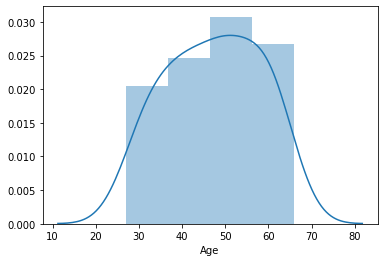

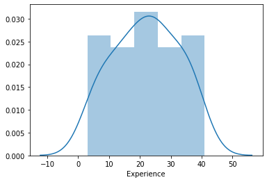

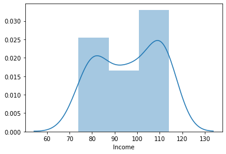

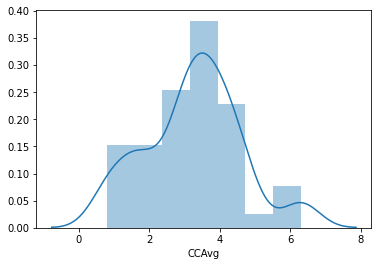

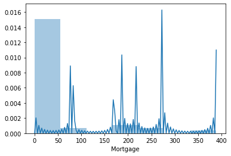

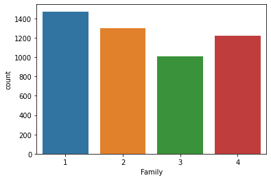

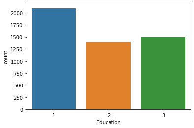

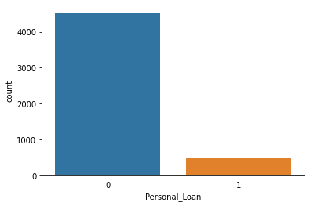

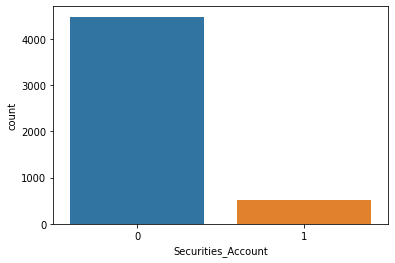

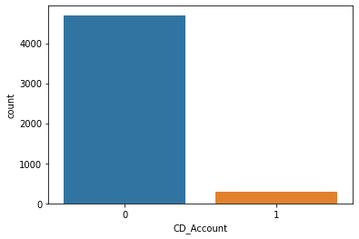

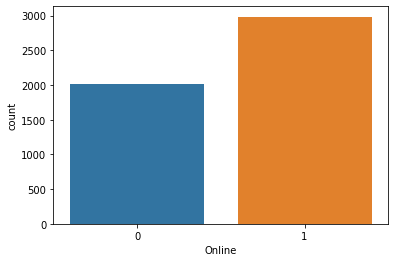

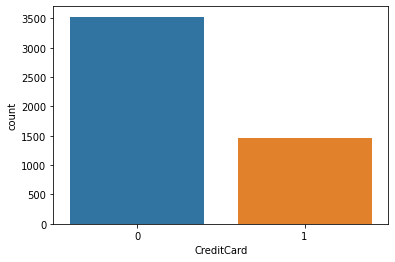

```python
distPlotList_up = ["Age", "Experience", "Income", "CCAvg", "Mortgage"]
countPlotList_up = [ "Family", "Education", "Personal_Loan",
                 "Securities_Account", "CD_Account", "Online", "CreditCard"]

for i in distPlotList_up:
    sns.distplot(wrong_prediction_FP[i])
    plt.show()

for i in countPlotList_up:
    sns.countplot(data[i])
    plt.show()
```

As expected, the noise does not particularly have pattern as it is nature/definition of noise.